# CB Insights Unicorns Notebook

# CB Insights Unicorns Analytics

## Introduction

We analyze data from CB Insights, on the global unicorn club [1].

## Packages

```r
library(tidyverse)
library(ggfortify)
library(GGally)
library(broom)
library(olsrr)
library(flextable)
```

## Functions

```r
source("catchphrases.R")
```

## Data

The data come from a spreadsheet from CB-Insights [1].

```r
library(readxl)
CB_Insights_Global_Unicorn_Club_2022 <- read_excel("CB-Insights_Global-Unicorn-Club_2022.xlsx",
    col_types = c("text", "numeric", "date",
        "text", "text", "text", "text"),
    skip = 2)
View(CB_Insights_Global_Unicorn_Club_2022)
```

## Data Description

```r
glimpse(CB_Insights_Global_Unicorn_Club_2022)
```

```
Rows: 1,066
Columns: 7
$ Company            <chr> "Bytedance", "SpaceX", "Stripe", "Klarna", "Epic Games", "Canva", "…
$ `Valuation ($B)`   <dbl> 140.0, 100.3, 95.0, 45.6, 42.0, 40.0, 40.0, 39.0, 38.0, 33.0, 32.0,…
$ `Date Added`       <dttm> 2017-04-07, 2012-12-01, 2014-01-23, 2011-12-12, 2018-10-26, 2018-0…
$ Country            <chr> "China", "United States", "United States", "Sweden", "United States…
$ Category           <chr> "Beijing", "Hawthorne", "San Francisco", "Stockholm", "Cary", "Surr…
$ Industry           <chr> "Artificial intelligence", "Other", "Fintech", "Fintech", "Other", …
$ `Select Investors` <chr> "Sequoia Capital China, SIG Asia Investments, Sina Weibo, Softbank …
```

## Data Wrangling

We want a short dataframe name, `cbi`. Also Category is really a City. So we rename that column.

```r
cbi = CB_Insights_Global_Unicorn_Club_2022 %>% rename(City=Category, Valuation=`Valuation ($B)`,
                                                     AddDate=`Date Added`, SelInvestors=`Select Investors` )
glimpse(cbi)
```

```
Rows: 1,066
Columns: 7
$ Company      <chr> "Bytedance", "SpaceX", "Stripe", "Klarna", "Epic Games", "Canva", "Checko…
$ Valuation    <dbl> 140.0, 100.3, 95.0, 45.6, 42.0, 40.0, 40.0, 39.0, 38.0, 33.0, 32.0, 27.0,…
$ AddDate      <dttm> 2017-04-07, 2012-12-01, 2014-01-23, 2011-12-12, 2018-10-26, 2018-01-08, …
$ Country      <chr> "China", "United States", "United States", "Sweden", "United States", "Au…
$ City         <chr> "Beijing", "Hawthorne", "San Francisco", "Stockholm", "Cary", "Surry Hill…
$ Industry     <chr> "Artificial intelligence", "Other", "Fintech", "Fintech", "Other", "Inter…
$ SelInvestors <chr> "Sequoia Capital China, SIG Asia Investments, Sina Weibo, Softbank Group"…
```

### Issues with Industry names

In Industry we see Artificial intelligence with and without a capital I for Intelligence. We will combine these by altering those with the large I to the small i.

We also see Fintech and Finttech. We will change the latter to the former.

```r
cbi[cbi$Industry=="Artificial Intelligence","Industry"] = "Artificial intelligence"
cbi[cbi$Industry=="Finttech","Industry"] = "Fintech"
unique(cbi$Industry)
```

```
 [1] "Artificial intelligence"             "Other"
 [3] "Fintech"                             "Internet software & services"
 [5] "Supply chain, logistics, & delivery" "Data management & analytics"
 [7] "E-commerce & direct-to-consumer"     "Edtech"
 [9] "Hardware"                            "Consumer & retail"
[11] "Health"                              "Auto & transportation"
[13] "Cybersecurity"                       "Mobile & telecommunications"
[15] "Travel"
```

We need short industry names, for display purposes.

```r
indshort = str_sub(cbi$Industry, 1, 14)
indshort %>% unique
```

```
 [1] "Artificial int" "Other"          "Fintech"        "Internet softw" "Supply chain, "
 [6] "Data managemen" "E-commerce & d" "Edtech"         "Hardware"       "Consumer & ret"
[11] "Health"         "Auto & transpo" "Cybersecurity"  "Mobile & telec" "Travel"
```

```r
cbi$IndShort = indshort
```

### Unique Industries, Countries, and Cities

What are the unique industries and countries, and cities?

```r
cp_length(cbi %>% pull(Industry) %>% unique %>% length,
          "Industries", dataname="unicorns")
```

```
There are 15 unique Industries in the unicorns dataset.
```

```r
cbi %>% pull(Industry) %>% unique
```

```
 [1] "Artificial intelligence"             "Other"
 [3] "Fintech"                             "Internet software & services"
 [5] "Supply chain, logistics, & delivery" "Data management & analytics"
 [7] "E-commerce & direct-to-consumer"     "Edtech"
 [9] "Hardware"                            "Consumer & retail"
[11] "Health"                              "Auto & transportation"
[13] "Cybersecurity"                       "Mobile & telecommunications"
[15] "Travel"
```

```r
cp_length(cbi %>% pull(Country) %>% unique %>% length,
          "Countries", dataname="unicorns")
```

```
There are 46 unique Countries in the unicorns dataset.
```

```r
cbi %>% pull(Country) %>% unique
```

```
 [1] "China"                "United States"        "Sweden"               "Australia"
 [5] "United Kingdom"       "Bahamas"              "India"                "Indonesia"
 [9] "Turkey"               "Germany"              "Hong Kong"            "Mexico"
[13] "Estonia"              "Canada"               "South Korea"          "Netherlands"
[17] "France"               "Israel"               "Finland"              "Colombia"
[21] "Belgium"              "Brazil"               "Denmark"              "Lithuania"
[25] "Austria"              "Ireland"              "Singapore"            "Vietnam"
[29] "United Arab Emirates" "Switzerland"          "Argentina"            "Spain"
[33] "Japan"                "Luxembourg"           "Nigeria"              "Philippines"
[37] "Senegal"              "Malaysia"             "Bermuda"              "Norway"
[41] "South Africa"         "Chile"                "Thailand"             "Czech Republic"
[45] "Croatia"              "Italy"
```

```r
cp_length(cbi %>% pull(City) %>% unique %>% length,
          "Cities", dataname="unicorns")
```

```
There are 255 unique Cities in the unicorns dataset.
```

```r
cbi %>% pull(City) %>% unique
```

```
  [1] "Beijing"               "Hawthorne"             "San Francisco"
  [4] "Stockholm"             "Cary"                  "Surry Hills"
  [7] "London"                NA                      "Jacksonville"
 [10] "Bengaluru"             "Shanghai"              "Jakarta"
 [13] "Shenzhen"              "Philadelphia"          "New York"
 [16] "Waltham"               "San Diego"             "Roseville"
 [19] "Changsha"              "Istanbul"              "Munich"
 [22] "Luohe"                 "Cheung Sha Wan"        "Walpole"
 [25] "Boston"                "Glendale"              "Berlin"
 [28] "Kirkland"              "Gurugram"              "Lerma de Villada"
 [31] "Mountain View"         "Fremont"               "Tallinn"
 [34] "San Jose"              "San Mateo"             "Chicago"
 [37] "Mumbai"                "Irving"                "Vancouver"
 [40] "Santa Clara"           "Seoul"                 "Pittsburgh"
 [43] "Palo Alto"             "Hangzhou"              "Toronto"
```

[output cut: 70 more lines]

### Classification of Industries

We’ll classify industries by Software and Hardware and Mixed, which might be either for the chosen industry.

```r
u =cbi %>% pull(Industry) %>% unique
u
```

```
 [1] "Artificial intelligence"             "Other"
 [3] "Fintech"                             "Internet software & services"
 [5] "Supply chain, logistics, & delivery" "Data management & analytics"
 [7] "E-commerce & direct-to-consumer"     "Edtech"
 [9] "Hardware"                            "Consumer & retail"
[11] "Health"                              "Auto & transportation"
[13] "Cybersecurity"                       "Mobile & telecommunications"
[15] "Travel"
```

Create the classes by index of the Industries.

```r
Soft = c(1, 3, 4, 6, 8, 13)
Hard = c(2, 5, 9, 10, 11, 12, 15)
Mixed = c(7, 14)

uS = u[Soft];cat("Soft=",uS, "\n")
```

```
Soft= Artificial intelligence Fintech Internet software & services Data management & analytics Edtech Cybersecurity
```

```r
uM = u[Mixed];cat("Mixed=",uM, "\n")
```

```
Mixed= E-commerce & direct-to-consumer Mobile & telecommunications
```

```r
uH = u[Hard];cat("Hard=",uH,"\n")
```

```
Hard= Other Supply chain, logistics, & delivery Hardware Consumer & retail Health Auto & transportation Travel
```

### Add Year/Month and Year/Quarter

Create functions to compute year-month and year-quarter.

Add to cbi dataframe to get `cbi_more`.

```r
cbi_more = cbi %>% mutate(Year=lubridate::year(AddDate),
                          Month=lubridate::month(AddDate),
                          YM = ym(AddDate),
                          YQ = yq(AddDate),
                          Class = factor(case_when (
                              Industry %in% uS ~ "Soft",
                              Industry %in% uM ~ "Mixed",
                              TRUE ~ "Hard") ) )
data.frame(cbi_more)
```

| Company | Valuation | AddDate | Country | City | Industry | SelInvestors | IndShort | Year | Month | YM | YQ | Class |
| --- | --- | --- | --- | --- | --- | --- | --- | --- | --- | --- | --- | --- |
| Bytedance | 140.00 | 2017-04-07 | China | Beijing | Artificial intelligence | Sequoia Capital China, SIG Asia Investments, Sina Weibo, Softbank Group | Artificial int | 2017 | 4 | 2017.250 | 2017.75 | Soft |
| SpaceX | 100.30 | 2012-12-01 | United States | Hawthorne | Other | Founders Fund, Draper Fisher Jurvetson, Rothenberg Ventures | Other | 2012 | 12 | 2012.917 | 2012.75 | Hard |
| Stripe | 95.00 | 2014-01-23 | United States | San Francisco | Fintech | Khosla Ventures, LowercaseCapital, capitalG | Fintech | 2014 | 1 | 2014.000 | 2014.00 | Soft |
| Klarna | 45.60 | 2011-12-12 | Sweden | Stockholm | Fintech | Institutional Venture Partners, Sequoia Capital, General Atlantic | Fintech | 2011 | 12 | 2011.917 | 2011.75 | Soft |
| Epic Games | 42.00 | 2018-10-26 | United States | Cary | Other | Tencent Holdings, KKR, Smash Ventures | Other | 2018 | 10 | 2018.750 | 2018.25 | Hard |
| Canva | 40.00 | 2018-01-08 | Australia | Surry Hills | Internet software & services | Sequoia Capital China, Blackbird Ventures, Matrix Partners | Internet softw | 2018 | 1 | 2018.000 | 2018.00 | Soft |
| Checkout.com | 40.00 | 2019-05-02 | United Kingdom | London | Fintech | Tiger Global Management, Insight Partners, DST Global | Fintech | 2019 | 5 | 2019.333 | 2019.00 | Soft |
| Instacart | 39.00 | 2014-12-30 | United States | San Francisco | Supply chain, logistics, & delivery | Khosla Ventures, Kleiner Perkins Caufield & Byers, Collaborative Fund | Supply chain, | 2014 | 12 | 2014.917 | 2014.75 | Hard |
| Databricks | 38.00 | 2019-02-05 | United States | San Francisco | Data management & analytics | Andreessen Horowitz, New Enterprise Associates, Battery Ventures | Data managemen | 2019 | 2 | 2019.083 | 2019.25 | Soft |
| Revolut | 33.00 | 2018-04-26 | United Kingdom | London | Fintech | index Ventures, DST Global, Ribbit Capital | Fintech | 2018 | 4 | 2018.250 | 2018.75 | Soft |

[output cut: 990 more lines]

## Examining Data

### Distribution of Valuation

The distribution is highly skewed. We plot all unicorns and the unicorns with valuation under $5B.

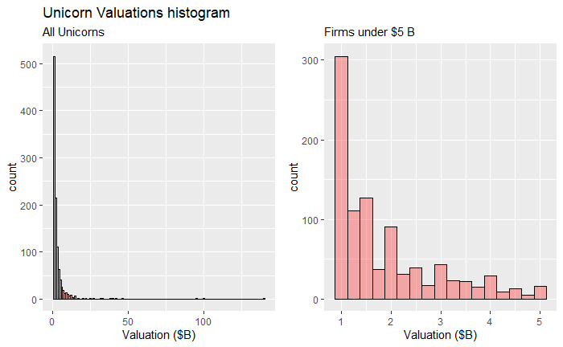

### Distribution of Logged Valuation

Let us investigate the log base 10 of Valuation, since these plots are almost exponentially declining. Note that on this plot 1.0 on the log(Valuation) axis represents $10B valuation.

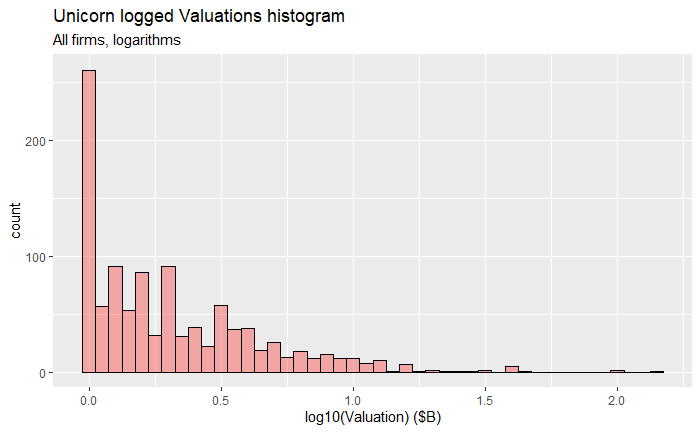

```r
ggplot(cbi_more, aes(x = log10(Valuation))) +
    geom_histogram(binwidth = .05, fill = "red1", color = "black", alpha=.3) +
    labs(title="Unicorn logged Valuations histogram",
       subtitle = "All firms, logarithms",
       x="log10(Valuation) ($B)")
```

Even for firms with less than $10B Valuation, there is a predominance of small fundings in the first bin, less than $\log10(Valuation) = .01$, or Valuation = $1.023293B.

### Distribution of Logged Valuation by Class

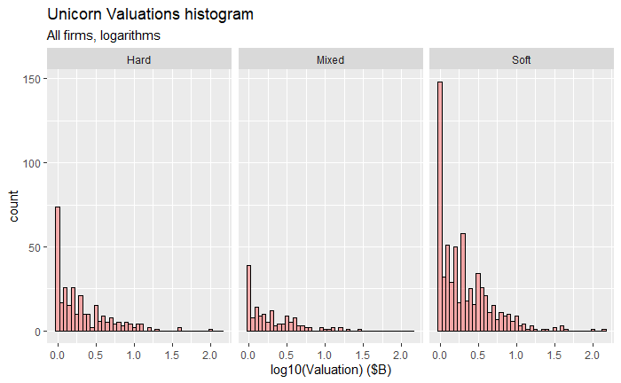

There are a lot more Class Soft firms.

## Distribution by AddDate

There are fewer cases before 2016.

```r
cbi_more %>% filter(Year<2016) %>% arrange(AddDate)
```

| Company | Valuation | AddDate | Country | City | Industry | SelInvestors | IndShort | Year | Month | YM | YQ | Class |
| --- | --- | --- | --- | --- | --- | --- | --- | --- | --- | --- | --- | --- |
| Veepee | 1.38 | 2007-07-02 | France | La Plaine Saint-Denis | E-commerce & direct-to-consumer | Summit Partners, Qatar Holding | E-commerce & d | 2007 | 7 | 2007.500 | 2007.50 | Mixed |
| Vice Media | 5.70 | 2011-04-02 | United States | Brooklyn | Internet software & services | Technology Crossover Ventures, A&E Television Networks | Internet softw | 2011 | 4 | 2011.250 | 2011.75 | Soft |
| Klarna | 45.60 | 2011-12-12 | Sweden | Stockholm | Fintech | Institutional Venture Partners, Sequoia Capital, General Atlantic | Fintech | 2011 | 12 | 2011.917 | 2011.75 | Soft |
| Trendy Group International | 2.00 | 2012-02-13 | Hong Kong | Kowloon | Consumer & retail | L Capital Partners | Consumer & ret | 2012 | 2 | 2012.083 | 2012.25 | Hard |
| Fanatics | 27.00 | 2012-06-06 | United States | Jacksonville | E-commerce & direct-to-consumer | SoftBank Group, Andreessen Horowitz, Temasek Holdings | E-commerce & d | 2012 | 6 | 2012.417 | 2012.25 | Mixed |
| SpaceX | 100.30 | 2012-12-01 | United States | Hawthorne | Other | Founders Fund, Draper Fisher Jurvetson, Rothenberg Ventures | Other | 2012 | 12 | 2012.917 | 2012.75 | Hard |
| Avant | 2.00 | 2012-12-17 | United States | Chicago | Artificial intelligence | RRE Ventures, Tiger Global, August Capital | Artificial int | 2012 | 12 | 2012.917 | 2012.75 | Soft |
| Mu Sigma | 1.50 | 2013-02-07 | United States | Northbrook | Data management & analytics | Sequoia Capital, General Atlantic | Data managemen | 2013 | 2 | 2013.083 | 2013.25 | Soft |
| Automattic | 7.50 | 2013-05-27 | United States | San Francisco | Internet software & services | Insight Venture Partners, Lowercase Capital, Polaris Partners | Internet softw | 2013 | 5 | 2013.333 | 2013.00 | Soft |
| Lookout | 1.00 | 2013-10-10 | United States | San Francisco | Cybersecurity | Accel Partners, Greylock Partners, Lowercase Capital | Cybersecurity | 2013 | 10 | 2013.750 | 2013.25 | Soft |

[output cut: 48 more lines]

```r
cbi_more %>% filter(Year<2016) %>% arrange(AddDate) %>% summarize(Count=n())
```

| Count |
| --- |
| 58 |

It appears there are 58, compared to 1066 cases in all, 5.4409006 percent of cases. So we filter the early ones out before plotting.

```r
ggplot(cbi_more %>% filter(Year>2016), aes(AddDate,log10(Valuation))) +
  geom_point() +
  geom_smooth(method="lm", se=T) +
  labs(title="Log of Valuation by Date",
       subtitle="With linear regression plot")
```

[output not shown]

There does not seem to be an increase in Valuation over time. In fact, a regression shows declining values of log10(Valuation). Some numeric tests of normality of residuals show non-normality. The $R^2=.07$, very low. The slope of the decline is computed in the tidy summary here.

```r
fit=lm(log10(Valuation)~AddDate, data=cbi_more %>% filter(Year>=2016) )
ols_test_normality(fit)
```

```
-----------------------------------------------
       Test             Statistic       pvalue
-----------------------------------------------
Shapiro-Wilk              0.9299         0.0000
Kolmogorov-Smirnov        0.1056         0.0000
Cramer-von Mises         177.9725        0.0000
Anderson-Darling         20.3412         0.0000
-----------------------------------------------
```

```r
summary(fit) %>% glance
```

| r.squared | adj.r.squared | sigma | statistic | p.value | df | df.residual | nobs |
| --- | --- | --- | --- | --- | --- | --- | --- |
| 0.06878402 | 0.06785836 | 0.3124598 | 74.30792 | 2.561544e-17 | 1 | 1006 | 1008 |

```r
summary(fit) %>% tidy(conf.int=T)
```

| term | estimate | std.error | statistic | p.value | conf.low | conf.high |
| --- | --- | --- | --- | --- | --- | --- |
| (Intercept) | 3.311612e+00 | 3.484562e-01 | 9.503670 | 1.433157e-20 | 2.627828e+00 | 3.995396e+00 |
| AddDate | -1.877194e-09 | 2.177668e-10 | -8.620204 | 2.561544e-17 | -2.304524e-09 | -1.449865e-09 |

## Valuation Groups by Date Added

The frequency of unicorns increases as we go along. One question is whether the Valuations also increase. This issue is clouded because of the variety of funding strategies, from Series A investments to Series B and C, and later on SPAC investments, with the recently emerging Private Investment in Public Equity) (PIPE) investments. We do not know the discounts or costs to the startup required for each type of investment. However, we are looking at valuations today. `TotVal` is our shorthand for the sum of Valuation in a group of observations.

We create summary dataframes by month using YM, by quarter using YQ, and by Class using Class, and plot them.

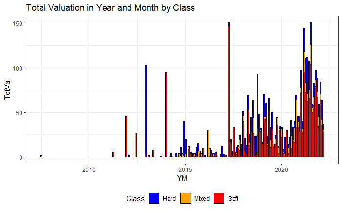

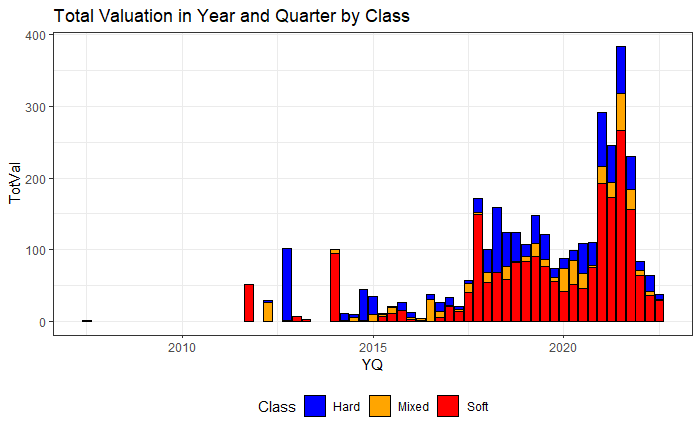

Clearly there are more Class S unicorns than Classes H and W. There is also growth with time in Total Valuation. What kind of fit is there to this growth in total valuation by month? by quarter?

### By Month

A linear model fitting log(Valuation) to TotVal is performed, after experimentation with linear and polynomial fits shows it is better. First we record the linear regression. Then we run the log regression. For the log regression, three of the OLS residual normality tests show normal residuals at the .05 sdignificance level. We report the overall summary and the coefficients.

```r
fit.sumval_exp=lm(log(TotVal)~YM, data=cbi_m)
ols_test_normality(fit.sumval_exp)
```

```
-----------------------------------------------
       Test             Statistic       pvalue
-----------------------------------------------
Shapiro-Wilk              0.9894         0.1034
Kolmogorov-Smirnov        0.0462         0.7341
Cramer-von Mises         13.7776         0.0000
Anderson-Darling          0.4793         0.2323
-----------------------------------------------
```

```r
summary(fit.sumval_exp) %>% glance
```

| r.squared | adj.r.squared | sigma | statistic | p.value | df | df.residual | nobs |
| --- | --- | --- | --- | --- | --- | --- | --- |
| 0.1287348 | 0.1247565 | 1.196968 | 32.35861 | 4.077755e-08 | 1 | 219 | 221 |

```r
summary(fit.sumval_exp) %>% tidy(conf.int=T)
```

| term | estimate | std.error | statistic | p.value | conf.low | conf.high |
| --- | --- | --- | --- | --- | --- | --- |
| (Intercept) | -353.7926000 | 62.54864288 | -5.656279 | 4.803564e-08 | -477.0669285 | -230.5182715 |
| YM | 0.1762673 | 0.03098681 | 5.688463 | 4.077755e-08 | 0.1151968 | 0.2373378 |

Plotting the regression results, we have

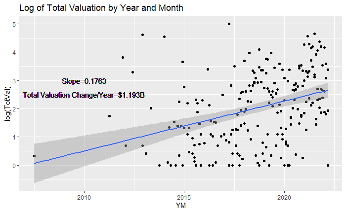

```r
ggplot(cbi_m) +
  geom_point(aes(YM, log(TotVal))) +
  geom_smooth(aes(YM, log(TotVal)), method="lm", se=T, formula='y~x') +
  geom_text(aes(x=2010, y=3, label=paste0("Slope=",round(coef(fit.sumval_exp)[2], digits=4)))) +
  geom_text(aes(x=2010,y=2.5,
                label=paste0("Total Valuation Change/Year=$",
                             round(exp(coef(fit.sumval_exp)[2]), digits=3),
                             "B"))) +
  labs(title="Log of Total Valuation by Year and Month")
```

### Structural Change

Is there a structural change in TotVal over this period? We first plot actual TotVal rather than the logs to check, with a few of the high-Total Valuation months before 2021. There were too many in 2021 and later.

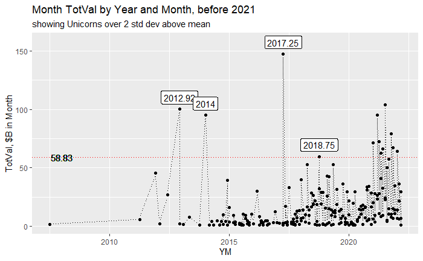

This graph shows that there appears to be a break at the end of 2020 when the amount of valuation in a month increases much faster. The 2 standard-deviation line shows four anomalous unicorns two standard deviations above the mean of TotVal for a month, prior to 2019, but only a slight increase overall, perhaps not significant. A Chow Test might confirm breaks. Or the break might be later.

```
The breakpoint is at observation 59 183 .

    Chow test

data:  TotVal ~ YM
F = 4.365, p-value = 0.01385


    Chow test

data:  TotVal ~ YM
F = 11.559, p-value = 1.697e-05
```

| Class | YM | TotVal | Break |
| --- | --- | --- | --- |
| Hard | 2017.250 | 2.24 | 59 |
| Hard | 2021.167 | 26.39 | 183 |

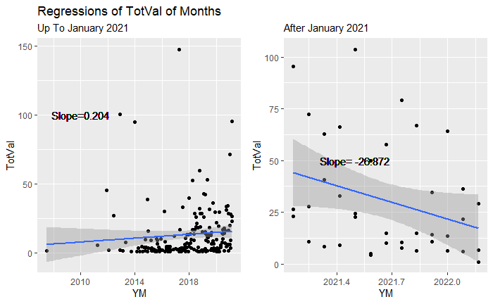

The graphs show that before the start of 2021 the growth was $.2B per year, but after 2021 started the drop was $26B per year, a dramatic decline in the size of the Total Valuation in a month.

### Particular Peaks

There were in addition peaks in particular months; January 2014 and December 2012. Those big bumps did not hold for a trend. They might be due to one large firm in each period. Here are the months greater than$ 58.83B Total Valuation. There are only 4 large ones before 2021.

```
There are 13 unique TotVal over $58.83B in the Monthly TotVal dataset.
```

| Class | YM | TotVal |
| --- | --- | --- |
| Hard | 2012.917 | 100.30 |
| Soft | 2014.000 | 95.00 |
| Soft | 2017.250 | 147.60 |
| Hard | 2018.750 | 59.62 |
| Soft | 2021.000 | 71.60 |
| Soft | 2021.167 | 95.34 |
| Soft | 2021.250 | 72.33 |
| Soft | 2021.333 | 62.70 |
| Soft | 2021.417 | 66.18 |
| Soft | 2021.500 | 103.75 |

[output cut: 3 more lines]

Only 4 months are before 2021. Here are the records in those periods before 2021.

```r
cbi_more %>% filter(between(YM,2012.91,2012.92)) %>%
  dplyr::select(-Industry,-City,-SelInvestors)
```

| Company | Valuation | AddDate | Country | IndShort | Year | Month | YM | YQ | Class |
| --- | --- | --- | --- | --- | --- | --- | --- | --- | --- |
| SpaceX | 100.3 | 2012-12-01 | United States | Other | 2012 | 12 | 2012.917 | 2012.75 | Hard |
| Avant | 2.0 | 2012-12-17 | United States | Artificial int | 2012 | 12 | 2012.917 | 2012.75 | Soft |

```r
cbi_more %>% filter(YM==2014.00) %>%
  dplyr::select(-Industry,-City,-SelInvestors)
```

| Company | Valuation | AddDate | Country | IndShort | Year | Month | YM | YQ | Class |
| --- | --- | --- | --- | --- | --- | --- | --- | --- | --- |
| Stripe | 95 | 2014-01-23 | United States | Fintech | 2014 | 1 | 2014 | 2014 | Soft |

```r
cbi_more %>% filter(YM==2017.25) %>%
  dplyr::select(-Industry,-City,-SelInvestors)
```

| Company | Valuation | AddDate | Country | IndShort | Year | Month | YM | YQ | Class |
| --- | --- | --- | --- | --- | --- | --- | --- | --- | --- |
| Bytedance | 140.00 | 2017-04-07 | China | Artificial int | 2017 | 4 | 2017.25 | 2017.75 | Soft |
| Rubrik | 4.00 | 2017-04-28 | United States | Data managemen | 2017 | 4 | 2017.25 | 2017.75 | Soft |
| Quora | 2.00 | 2017-04-21 | United States | Internet softw | 2017 | 4 | 2017.25 | 2017.75 | Soft |
| Afiniti | 1.60 | 2017-04-14 | Bermuda | Artificial int | 2017 | 4 | 2017.25 | 2017.75 | Soft |
| BrewDog | 1.24 | 2017-04-10 | United Kingdom | Consumer & ret | 2017 | 4 | 2017.25 | 2017.75 | Hard |
| Mobvoi | 1.00 | 2017-04-06 | China | Consumer & ret | 2017 | 4 | 2017.25 | 2017.75 | Hard |
| Zhuan Zhuan | 1.00 | 2017-04-18 | China | E-commerce & d | 2017 | 4 | 2017.25 | 2017.75 | Mixed |

In 2012, Spacex was the big dog at $100B. In 2014, Stripe was valued at $95B. In 2017, 7 more companies appear, but only Bytedance has a valuation over $4B, at a level of $140B.

2018 shows a different pattern.

```r
cbi_more %>% arrange(YM) %>% filter(YM == 2018.00) %>%
  dplyr::select(-Industry,-City,-SelInvestors)
```

| Company | Valuation | AddDate | Country | IndShort | Year | Month | YM | YQ | Class |
| --- | --- | --- | --- | --- | --- | --- | --- | --- | --- |
| Canva | 40.0 | 2018-01-08 | Australia | Internet softw | 2018 | 1 | 2018 | 2018 | Soft |
| Ziroom | 6.6 | 2018-01-17 | China | E-commerce & d | 2018 | 1 | 2018 | 2018 | Mixed |
| Cao Cao Mobility | 1.6 | 2018-01-17 | China | Auto & transpo | 2018 | 1 | 2018 | 2018 | Hard |
| Cabify | 1.4 | 2018-01-22 | Spain | Auto & transpo | 2018 | 1 | 2018 | 2018 | Hard |
| Hive Box | 1.4 | 2018-01-23 | China | Supply chain, | 2018 | 1 | 2018 | 2018 | Hard |

```r
cbi_more %>% arrange(YM) %>% filter(YM == 2018.25) %>%
  dplyr::select(-Industry,-City,-SelInvestors)
```

| Company | Valuation | AddDate | Country | IndShort | Year | Month | YM | YQ | Class |
| --- | --- | --- | --- | --- | --- | --- | --- | --- | --- |
| Revolut | 33.00 | 2018-04-26 | United Kingdom | Fintech | 2018 | 4 | 2018.25 | 2018.75 | Soft |
| Discord | 15.00 | 2018-04-20 | United States | Internet softw | 2018 | 4 | 2018.25 | 2018.75 | Soft |
| Flexport | 8.00 | 2018-04-30 | United States | Supply chain, | 2018 | 4 | 2018.25 | 2018.75 | Hard |
| Youxia Motors | 3.35 | 2018-04-02 | China | Auto & transpo | 2018 | 4 | 2018.25 | 2018.75 | Hard |
| Xinchao Media | 2.00 | 2018-04-09 | China | Internet softw | 2018 | 4 | 2018.25 | 2018.75 | Soft |
| BYTON | 2.50 | 2018-04-20 | China | Auto & transpo | 2018 | 4 | 2018.25 | 2018.75 | Hard |
| AIWAYS | 1.78 | 2018-04-16 | China | Auto & transpo | 2018 | 4 | 2018.25 | 2018.75 | Hard |
| DeepBlue Technology | 1.35 | 2018-04-16 | China | Artificial int | 2018 | 4 | 2018.25 | 2018.75 | Soft |
| WTOIP | 1.27 | 2018-04-08 | China | Internet softw | 2018 | 4 | 2018.25 | 2018.75 | Soft |
| Dxy.cn | 1.00 | 2018-04-10 | China | Health | 2018 | 4 | 2018.25 | 2018.75 | Hard |

```r
cbi_more %>% arrange(YM) %>% filter(YM == 2018.50) %>%
  dplyr::select(-Industry,-City,-SelInvestors)
```

| Company | Valuation | AddDate | Country | IndShort | Year | Month | YM | YQ | Class |
| --- | --- | --- | --- | --- | --- | --- | --- | --- | --- |
| SHEIN | 15.00 | 2018-07-03 | China | E-commerce & d | 2018 | 7 | 2018.5 | 2018.5 | Mixed |
| Bitmain Technologies | 12.00 | 2018-07-06 | China | Hardware | 2018 | 7 | 2018.5 | 2018.5 | Hard |
| Pony.ai | 8.50 | 2018-07-11 | United States | Artificial int | 2018 | 7 | 2018.5 | 2018.5 | Soft |
| Automation Anywhere | 6.80 | 2018-07-02 | United States | Artificial int | 2018 | 7 | 2018.5 | 2018.5 | Soft |
| Greensill | 4.00 | 2018-07-16 | United Kingdom | Fintech | 2018 | 7 | 2018.5 | 2018.5 | Soft |
| Medlinker | 3.92 | 2018-07-31 | China | Health | 2018 | 7 | 2018.5 | 2018.5 | Hard |
| Zuoyebang | 3.00 | 2018-07-18 | China | Edtech | 2018 | 7 | 2018.5 | 2018.5 | Soft |
| Jusfoun Big Data | 1.62 | 2018-07-09 | China | Data managemen | 2018 | 7 | 2018.5 | 2018.5 | Soft |
| Unisound | 1.31 | 2018-07-19 | China | Artificial int | 2018 | 7 | 2018.5 | 2018.5 | Soft |
| Starry | 1.29 | 2018-07-03 | United States | Mobile & telec | 2018 | 7 | 2018.5 | 2018.5 | Mixed |

[output cut: 6 more lines]

```r
cbi_more %>% arrange(YM) %>% filter(YM == 2018.75) %>%
  dplyr::select(-Industry,-City,-SelInvestors)
```

| Company | Valuation | AddDate | Country | IndShort | Year | Month | YM | YQ | Class |
| --- | --- | --- | --- | --- | --- | --- | --- | --- | --- |
| Epic Games | 42.00 | 2018-10-26 | United States | Other | 2018 | 10 | 2018.75 | 2018.25 | Hard |
| Devoted Health | 12.60 | 2018-10-16 | United States | Health | 2018 | 10 | 2018.75 | 2018.25 | Hard |
| Brex | 12.30 | 2018-10-05 | United States | Fintech | 2018 | 10 | 2018.75 | 2018.25 | Soft |
| Talkdesk | 10.00 | 2018-10-03 | United States | Internet softw | 2018 | 10 | 2018.75 | 2018.25 | Soft |
| Monzo | 4.50 | 2018-10-31 | United Kingdom | Fintech | 2018 | 10 | 2018.75 | 2018.25 | Soft |
| Cloudwalk | 3.32 | 2018-10-08 | China | Artificial int | 2018 | 10 | 2018.75 | 2018.25 | Soft |
| PAX | 1.70 | 2018-10-22 | United States | Consumer & ret | 2018 | 10 | 2018.75 | 2018.25 | Hard |
| GPclub | 1.32 | 2018-10-22 | South Korea | Other | 2018 | 10 | 2018.75 | 2018.25 | Hard |
| Tresata | 1.00 | 2018-10-10 | United States | Fintech | 2018 | 10 | 2018.75 | 2018.25 | Soft |
| Momenta | 1.00 | 2018-10-17 | China | Artificial int | 2018 | 10 | 2018.75 | 2018.25 | Soft |

[output cut: 3 more lines]

In January 2018, there were only 5; only Canva at $40B is large; Ziroom at $6B was substantially smaller, and the others are between $1B and $2B

In April 2018, there were 10; the top 3 (Revolut, Discord, and Flexport) were all over $8B; the others under $3.4B.

In July 2018, there were 16. SHEIN at $15B and Bitmain at $12B topped $10B each, three others (Pony.ai, Automation Anywhere, and Greensill) were over $4B, and the rest smaller.

In October 2018 the number was 13. Epic Games led with $42B; three others (Devoted Health, Brex, and Talkdesk) were over $10B, Monzo was at $4.5B, and the rest lower.

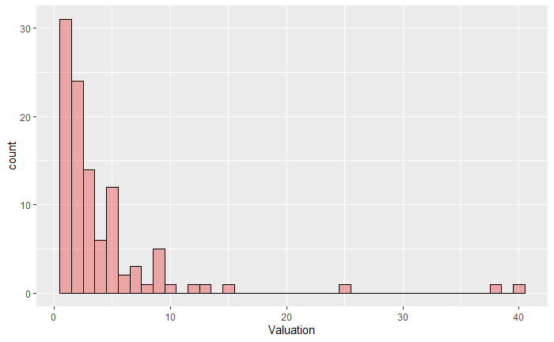

In 2020 on the other hand, things mushroomed out of control.

```r
cbi_more %>% arrange(YM, desc(Valuation)) %>% filter(between(YM, 2020, 2020.99)) %>%
  dplyr::select(-Industry,-City,-SelInvestors)
```

| Company | Valuation | AddDate | Country | IndShort | Year | Month | YM | YQ | Class |
| --- | --- | --- | --- | --- | --- | --- | --- | --- | --- |
| Snyk | 8.60 | 2020-01-21 | United States | Cybersecurity | 2020 | 1 | 2020.000 | 2020.00 | Soft |
| Pine Labs | 6.00 | 2020-01-24 | India | Fintech | 2020 | 1 | 2020.000 | 2020.00 | Soft |
| Moon Active | 5.00 | 2020-01-26 | Israel | Mobile & telec | 2020 | 1 | 2020.000 | 2020.00 | Mixed |
| HighRadius | 3.10 | 2020-01-07 | United States | Fintech | 2020 | 1 | 2020.000 | 2020.00 | Soft |
| Loft | 2.90 | 2020-01-03 | Brazil | E-commerce & d | 2020 | 1 | 2020.000 | 2020.00 | Mixed |
| AppsFlyer | 2.00 | 2020-01-21 | United States | Mobile & telec | 2020 | 1 | 2020.000 | 2020.00 | Mixed |
| Verkada | 1.60 | 2020-01-29 | United States | Cybersecurity | 2020 | 1 | 2020.000 | 2020.00 | Soft |
| Justworks | 1.43 | 2020-01-28 | United States | Internet softw | 2020 | 1 | 2020.000 | 2020.00 | Soft |
| Sisense | 1.10 | 2020-01-09 | United States | Data managemen | 2020 | 1 | 2020.000 | 2020.00 | Soft |
| Alto Pharmacy | 1.00 | 2020-01-30 | United States | Health | 2020 | 1 | 2020.000 | 2020.00 | Hard |

[output cut: 98 more lines]

```r
cbi_more %>% arrange(YM, desc(Valuation)) %>% filter(between(YM, 2020, 2020.99) & Valuation>10) %>%
  dplyr::select(-Industry,-City,-SelInvestors)
```

| Company | Valuation | AddDate | Country | IndShort | Year | Month | YM | YQ | Class |
| --- | --- | --- | --- | --- | --- | --- | --- | --- | --- |
| Yuanqi Senlin | 15 | 2020-03-01 | China | Consumer & ret | 2020 | 3 | 2020.167 | 2020.50 | Hard |
| Xingsheng Selected | 12 | 2020-07-22 | China | E-commerce & d | 2020 | 7 | 2020.500 | 2020.50 | Mixed |
| goPuff | 15 | 2020-10-08 | United States | E-commerce & d | 2020 | 10 | 2020.750 | 2020.25 | Mixed |

```r
cbi_more %>% arrange(YM, desc(Valuation)) %>% filter(between(YM, 2020, 2020.99) &
                                                     between(Valuation, 4, 9.99) ) %>%
  dplyr::select(-Industry,-City,-SelInvestors)
```

| Company | Valuation | AddDate | Country | IndShort | Year | Month | YM | YQ | Class |
| --- | --- | --- | --- | --- | --- | --- | --- | --- | --- |
| Snyk | 8.60 | 2020-01-21 | United States | Cybersecurity | 2020 | 1 | 2020.000 | 2020.00 | Soft |
| Pine Labs | 6.00 | 2020-01-24 | India | Fintech | 2020 | 1 | 2020.000 | 2020.00 | Soft |
| Moon Active | 5.00 | 2020-01-26 | Israel | Mobile & telec | 2020 | 1 | 2020.000 | 2020.00 | Mixed |
| SVOLT | 6.51 | 2020-06-08 | China | Auto & transpo | 2020 | 6 | 2020.417 | 2020.25 | Hard |
| Postman | 5.60 | 2020-06-11 | United States | Internet softw | 2020 | 6 | 2020.417 | 2020.25 | Soft |
| FiveTran | 5.60 | 2020-06-30 | United States | Data managemen | 2020 | 6 | 2020.417 | 2020.25 | Soft |
| Ro | 7.00 | 2020-07-27 | United States | Health | 2020 | 7 | 2020.500 | 2020.50 | Hard |
| National Stock Exchange of India | 6.50 | 2020-07-01 | India | Fintech | 2020 | 7 | 2020.500 | 2020.50 | Soft |
| Gong | 7.25 | 2020-08-12 | United States | Artificial int | 2020 | 8 | 2020.583 | 2020.75 | Soft |
| Rippling | 6.50 | 2020-08-04 | United States | Internet softw | 2020 | 8 | 2020.583 | 2020.75 | Soft |

[output cut: 21 more lines]

Overall in 2020 there were 108 unicorns listed, added in every month of the year. However, only 3 exceeded $10B, and those were Yuanqi Senlin ($15B), Xingsheng Selected ($12B), and goPuff ($15B). There were 31 firms in excess of $4B. Clearly the volume was high, but the size of the unicorns was smaller.

This matches the perception we got from the linear regressions. Size of unicorns is shrinking, but number is increasing.

Does this mean simply that they have not had enough time to get big?

Looking at 2021 we see this.

```r
cbi_more %>% arrange(YM, desc(Valuation)) %>% filter(between(YM, 2021, 2021.99)) %>%
  dplyr::select(-Industry,-City,-SelInvestors)
```

| Company | Valuation | AddDate | Country | IndShort | Year | Month | YM | YQ | Class |
| --- | --- | --- | --- | --- | --- | --- | --- | --- | --- |
| Lacework | 8.30 | 2021-01-07 | United States | Cybersecurity | 2021 | 1 | 2021.000 | 2021.00 | Soft |
| Personio | 6.30 | 2021-01-19 | Germany | Internet softw | 2021 | 1 | 2021.000 | 2021.00 | Soft |
| Hinge Health | 6.20 | 2021-01-06 | United States | Health | 2021 | 1 | 2021.000 | 2021.00 | Hard |
| Workato | 5.70 | 2021-01-12 | United States | Internet softw | 2021 | 1 | 2021.000 | 2021.00 | Soft |
| Mambu | 5.50 | 2021-01-06 | Netherlands | Fintech | 2021 | 1 | 2021.000 | 2021.00 | Soft |
| Cockroach Labs | 5.00 | 2021-01-12 | United States | Data managemen | 2021 | 1 | 2021.000 | 2021.00 | Soft |
| Color | 4.60 | 2021-01-04 | United States | Health | 2021 | 1 | 2021.000 | 2021.00 | Hard |
| PointClickCare | 4.00 | 2021-01-07 | Canada | Internet softw | 2021 | 1 | 2021.000 | 2021.00 | Soft |
| Zapier | 4.00 | 2021-01-14 | United States | Internet softw | 2021 | 1 | 2021.000 | 2021.00 | Soft |
| Clubhouse | 4.00 | 2021-01-24 | United States | Mobile & telec | 2021 | 1 | 2021.000 | 2021.00 | Mixed |

[output cut: 509 more lines]

```r
cbi_more %>% arrange(YM, desc(Valuation)) %>% filter(between(YM, 2021, 2021.99) & Valuation>10) %>%
  dplyr::select(-Industry,-City,-SelInvestors)
```

| Company | Valuation | AddDate | Country | IndShort | Year | Month | YM | YQ | Class |
| --- | --- | --- | --- | --- | --- | --- | --- | --- | --- |
| Getir | 11.80 | 2021-03-26 | Turkey | E-commerce & d | 2021 | 3 | 2021.167 | 2021.50 | Mixed |
| J&T Express | 20.00 | 2021-04-07 | Indonesia | Supply chain, | 2021 | 4 | 2021.250 | 2021.75 | Hard |
| Weilong | 10.88 | 2021-05-08 | China | Consumer & ret | 2021 | 5 | 2021.333 | 2021.00 | Hard |
| ZongMu Technology | 11.40 | 2021-06-03 | China | Auto & transpo | 2021 | 6 | 2021.417 | 2021.25 | Hard |
| FTX | 32.00 | 2021-07-20 | Bahamas | Fintech | 2021 | 7 | 2021.500 | 2021.50 | Soft |
| OpenSea | 13.30 | 2021-07-20 | United States | E-commerce & d | 2021 | 7 | 2021.500 | 2021.50 | Mixed |
| GoodLeap | 12.00 | 2021-10-13 | United States | Internet softw | 2021 | 10 | 2021.750 | 2021.25 | Soft |
| Bolt | 11.00 | 2021-10-08 | United States | Fintech | 2021 | 10 | 2021.750 | 2021.25 | Soft |
| Alchemy | 10.20 | 2021-10-28 | United States | Fintech | 2021 | 10 | 2021.750 | 2021.25 | Soft |

```r
cbi_more %>% arrange(YM, desc(Valuation)) %>% filter(between(YM, 2021, 2021.99) &
                                                     between(Valuation, 4, 9.99) ) %>%
  dplyr::select(-Industry,-City,-SelInvestors)
```

| Company | Valuation | AddDate | Country | IndShort | Year | Month | YM | YQ | Class |
| --- | --- | --- | --- | --- | --- | --- | --- | --- | --- |
| Lacework | 8.30 | 2021-01-07 | United States | Cybersecurity | 2021 | 1 | 2021.000 | 2021.00 | Soft |
| Personio | 6.30 | 2021-01-19 | Germany | Internet softw | 2021 | 1 | 2021.000 | 2021.00 | Soft |
| Hinge Health | 6.20 | 2021-01-06 | United States | Health | 2021 | 1 | 2021.000 | 2021.00 | Hard |
| Workato | 5.70 | 2021-01-12 | United States | Internet softw | 2021 | 1 | 2021.000 | 2021.00 | Soft |
| Mambu | 5.50 | 2021-01-06 | Netherlands | Fintech | 2021 | 1 | 2021.000 | 2021.00 | Soft |
| Cockroach Labs | 5.00 | 2021-01-12 | United States | Data managemen | 2021 | 1 | 2021.000 | 2021.00 | Soft |
| Color | 4.60 | 2021-01-04 | United States | Health | 2021 | 1 | 2021.000 | 2021.00 | Hard |
| PointClickCare | 4.00 | 2021-01-07 | Canada | Internet softw | 2021 | 1 | 2021.000 | 2021.00 | Soft |
| Zapier | 4.00 | 2021-01-14 | United States | Internet softw | 2021 | 1 | 2021.000 | 2021.00 | Soft |
| Clubhouse | 4.00 | 2021-01-24 | United States | Mobile & telec | 2021 | 1 | 2021.000 | 2021.00 | Mixed |

[output cut: 38 more lines]

Now there are 519 unicorns. Only 9 of them are valued at $10B or more. And 48 are valued between $4B and $9.9B; most are smaller.

### By Quarter

We try Quarterly simply to eliminate it. Again the log TotVal regression is significantly better.

```r
# fit.sumvalq = lm(TotVal~YQ, data=cbi_q)
# summary(fit.sumvalq)
# fit.sumval2q = lm(`sum.Valuation.`~poly(YQ,2), data=cbi_dfq)
# summary(fit.sumval2q)
# fit.sumval3q = lm(`sum.Valuation.`~poly(YQ,3), data=cbi_dfq)
# summary(fit.sumval3q)
fit.sumval_expq=lm(log(TotVal)~YQ, data=cbi_q)
ols_test_normality(fit.sumval_expq)
```

```
-----------------------------------------------
       Test             Statistic       pvalue
-----------------------------------------------
Shapiro-Wilk              0.9945         0.9506
Kolmogorov-Smirnov        0.0597         0.8489
Cramer-von Mises          6.5125         0.0000
Anderson-Darling          0.1968         0.8868
-----------------------------------------------
```

```r
summary(fit.sumval_expq)
```

```
Call:
lm(formula = log(TotVal) ~ YQ, data = cbi_q)

Residuals:
    Min      1Q  Median      3Q     Max
-3.5963 -0.8520  0.0446  0.7873  2.9275

Coefficients:
              Estimate Std. Error t value Pr(>|t|)
(Intercept) -393.77182   84.41708  -4.665 9.32e-06 ***
YQ             0.19647    0.04183   4.697 8.19e-06 ***
---
Signif. codes:  0 ‘***’ 0.001 ‘**’ 0.01 ‘*’ 0.05 ‘.’ 0.1 ‘ ’ 1

Residual standard error: 1.27 on 103 degrees of freedom
Multiple R-squared:  0.1764,    Adjusted R-squared:  0.1684
F-statistic: 22.06 on 1 and 103 DF,  p-value: 8.19e-06
```

The log fit shows that an exponential trend is probable. We can accept the hypothesis that residuals of the log regression are normal. Plotting the log regression with the data gives

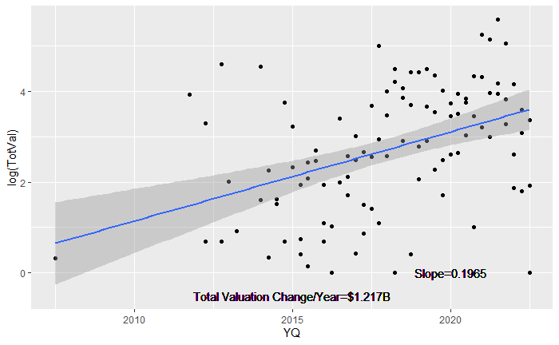

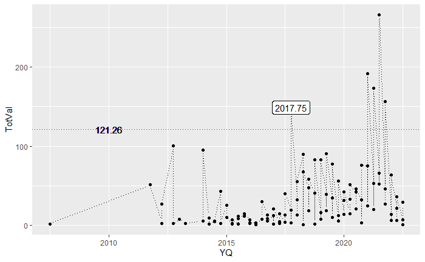

## Parsing by Industry

Which industries gain higher Valuations? And Which Industries have more unicorns?

### Valuation by Industry

```
argument.
Rows: 124
Columns: 4
Groups: IndShort, Year [124]
$ IndShort <chr> "Artificial int", "Artificial int", "Artificial int", "Artificial int", "Arti…
$ Year     <dbl> 2012, 2015, 2016, 2017, 2018, 2019, 2020, 2021, 2022, 2014, 2015, 2016, 2018,…
$ Class    <fct> Soft, Soft, Soft, Soft, Soft, Soft, Soft, Soft, Soft, Hard, Hard, Hard, Hard,…
$ TotVal   <dbl> 2.00, 3.30, 1.00, 149.10, 37.35, 58.76, 12.13, 50.81, 13.40, 7.50, 2.00, 1.50…
```

| IndShort | Year | Class | TotVal |
| --- | --- | --- | --- |
| Artificial int | 2012 | Soft | 2.00 |
| Artificial int | 2015 | Soft | 3.30 |
| Artificial int | 2016 | Soft | 1.00 |
| Artificial int | 2017 | Soft | 149.10 |
| Artificial int | 2018 | Soft | 37.35 |
| Artificial int | 2019 | Soft | 58.76 |
| Artificial int | 2020 | Soft | 12.13 |
| Artificial int | 2021 | Soft | 50.81 |
| Artificial int | 2022 | Soft | 13.40 |
| Auto & transpo | 2014 | Hard | 7.50 |

[output cut: 114 more lines]

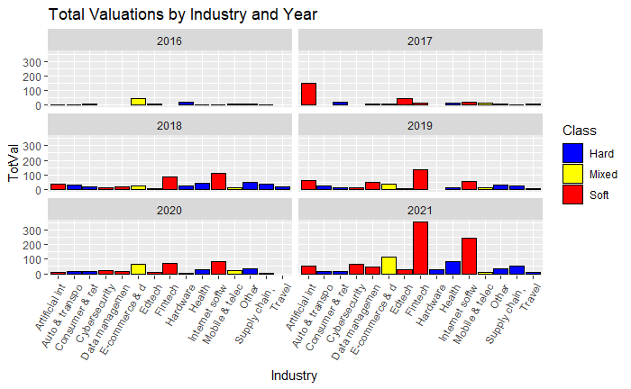

```r
px=ggplot(x %>% filter(between(Year,2016,2021) )) +
  geom_col(aes(IndShort,TotVal, fill=Class), color="black", alpha=1) +
  scale_fill_manual(values = c("blue","yellow","red")) +
  theme(axis.text.x = element_text(angle = 60, vjust = 1, hjust=1)) +
  labs(title="Total Valuations by Industry and Year",
       x="Industry") +
  facet_wrap(vars(Year), ncol=2)
px
```

```r
# ggsave("Valuations by Industry and Year.jpg", plot=px, device="jpeg", height=7 )
```

Total Valuation in 2021 is higher in specific industries, particularly Fintech and Internet services & software. These two have been big since 2018. In 2017 it was far and away Artificial intelligence, with Edtech far behind. In 2016 it was E-commerce & direct-to-consumer. It’s clear the big valuations are occurring in areas which are not Hardware-related.

### Count by Industry

```r
y = cbi_more %>% arrange(Year, Industry) %>% group_by(IndShort, Year, Class) %>% summarize(Count=n())
```

```
argument.
```

```r
glimpse(y)
```

```
Rows: 124
Columns: 4
Groups: IndShort, Year [124]
$ IndShort <chr> "Artificial int", "Artificial int", "Artificial int", "Artificial int", "Arti…
$ Year     <dbl> 2012, 2015, 2016, 2017, 2018, 2019, 2020, 2021, 2022, 2014, 2015, 2016, 2018,…
$ Class    <fct> Soft, Soft, Soft, Soft, Soft, Soft, Soft, Soft, Soft, Hard, Hard, Hard, Hard,…
$ Count    <int> 1, 2, 1, 4, 13, 14, 3, 36, 9, 1, 1, 1, 11, 6, 5, 4, 2, 1, 3, 4, 6, 3, 1, 7, 1…
```

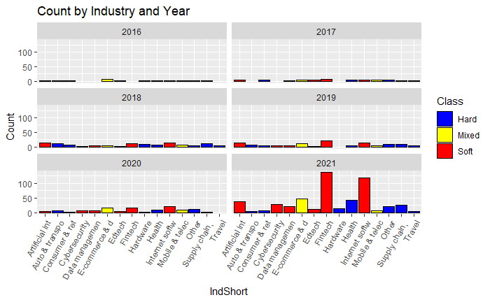

```r
py=ggplot(y %>% filter(between(Year,2016,2021) )) +
  geom_col(aes(IndShort,Count, fill=Class), color="black", alpha=1, orientation="x") +
  scale_fill_manual(values=c("blue","yellow","red")) +
  theme(axis.text.x = element_text(angle = 60, vjust = 1, hjust=1)) +
  labs(title="Count by Industry and Year") +
  facet_wrap(vars(Year), ncol=2)
py
```

```r
# ggsave("Counts by Industry and Year.jpg", plot=py, device="jpeg", height=7 )
```

If we look at counts of firms by Industry over these same years, we see that in 2021, Artificial intelligence, E-commerce & direct-to-consumer, Fintech, Health, and Internet software & services dominate. Supply chain, logistics & delivery has become noticeable, as has Cybersecurity.

## References

1. https://www.cbinsights.com/?utm_campaign=marketing_unicorns-list_2022-02
2. https://stackoverflow.com/questions/1735540/creating-a-pareto-chart-with-ggplot2-and-r
3. https://stats.stackexchange.com/questions/36212/what-tests-do-i-use-to-confirm-that-residuals-are-normally-distributed